# Exploring the HAB Index

Johnathan Evanilla

1/3/2022

# Introduction - Loading and Visualizing Data in Kaggle

In this tutorial, we will explore a timeseries called the “HAB Index,” which combines three components of seasonal Paralytic Shellfish Poison (PSP) outbreaks in coastal Maine.

This lab serves as an introduction to working in the Kaggle environment, data organization, visualization, and interpretation that you will conduct throughout the course. You can use the exercises here as a template for your future analyses.

For this course, we will be running R notebooks in Kaggle. These notebooks can also be run on your computer in R or R-studio. For reference, here are notes on installing R and R-studio.

Install R program at: http://cran.rstudio.com/ This site has options for download for Linux, Mac, and Windows

Install R-studio (R interface) http://www.rstudio.com/products/rstudio/download/ Under “installers” you should see options for Mac and Windows.

**Libraries / Packages**

R notebooks begin by loading in any libraries/packages that will be used. Here we are loading in libraries used for reading in data, manipulating data, and plotting/visualizing data.

If you are running R on your computer, you’ll first need to install each package with the install.packages() function.

```r
library(readr)
library(dplyr)
```

```r
library(ggplot2)
```

**Data Organization**

Good data organization and formatting is the foundation for your research project. Data files stored in proprietary formats, like excel spreadsheets, have readability and transferrability problems. Storing data in a universal, open, and machine-readable format will avoid problems. The most general format is a .csv format (comma separated values), in a columnar table format.

# Read HAB Index Data File

First, we can read in a csv file containing the HAB Indices from 1975 through 2021. A HAB Index is computed for Western and Eastern Maine coastal regions each year, split by Penobscot Bay. There are three components used to find the HAB Index: * Percent Toxic Stations - The percent of PSP sampling stations throughout the region that have at least one sample >40 (units) throughout the season. * Normalized Cummulative Toxicity - The sum of all toxicity scores from the region divided by the number of stations samples. * Duration of Toxic Season - The number of days between the first and last sample >40 (units) throughout the region.

| Bin # | % of toxic STATIONS | Cummulative Toxicity | Duration of toxicity |
| --- | --- | --- | --- |
| 1 | 0-20 | 0-500 | 0-50 |
| 2 | 21-40 | 501-1000 | 51-100 |
| 3 | 41-60 | 1001-1500 | 101-150 |
| 4 | 61-80 | 1501-2000 | 151-200 |
| 5 | 81-100 | >2000 | >200 |

```
## Rows: 47
## Columns: 17
## $ year                    <dbl> 1975, 1976, 1977, 1978, 1979, 1980, 1981, 1982…
## $ per_toxic_stations_west <dbl> 76.744186, 78.947368, 65.909091, 88.157895, 78…
## $ per_toxic_stations_east <dbl> 75.000000, 33.333333, 75.000000, 71.428571, 38…
## $ norm_tox_west           <dbl> 1316.441860, 804.263158, 2614.113636, 7496.236…
## $ norm_tox_east           <dbl> 847.500000, 127.250000, 136.500000, 533.742857…
## $ duration_west           <dbl> 161, 97, 195, 205, 161, 241, 234, 196, 125, 10…
## $ duration_east           <dbl> 80, 97, 40, 94, 55, 156, 197, 98, 140, 113, 12…
## $ hab_index_west          <dbl> 11, 8, 13, 15, 13, 14, 13, 10, 10, 12, 7, 15, …
## $ hab_index_east          <dbl> 8, 5, 6, 8, 5, 10, 7, 6, 6, 7, 8, 10, 6, 7, 8,…
## $ n_stations_w            <dbl> 43, 38, 44, 76, 82, 99, 93, 74, 68, 75, 60, 81…
## $ n_stations_e            <dbl> 12, 12, 8, 35, 18, 71, 55, 44, 59, 55, 42, 40,…
## $ n_toxic_w               <dbl> 33, 30, 29, 67, 64, 64, 71, 54, 53, 68, 25, 70…
## $ n_toxic_e               <dbl> 9, 4, 6, 25, 7, 36, 15, 20, 17, 25, 20, 17, 14…
## $ onset_west              <dbl> 91, 114, 111, 62, 108, 113, 12, 76, 111, 110, …
## $ onset_east              <dbl> 150, 125, 269, 137, 165, 135, 67, 173, 130, 12…
## $ end_west                <dbl> 252, 211, 306, 267, 269, 354, 246, 272, 236, 2…
## $ end_east                <dbl> 230, 222, 309, 231, 220, 291, 264, 271, 270, 2…
```

```
##       year      per_toxic_stations_west per_toxic_stations_east
##  Min.   :1975   Min.   : 0.00           Min.   : 0.00
##  1st Qu.:1986   1st Qu.:35.58           1st Qu.:28.17
##  Median :1998   Median :65.91           Median :42.50
##  Mean   :1998   Mean   :57.63           Mean   :41.66
##  3rd Qu.:2010   3rd Qu.:77.99           3rd Qu.:50.96
##  Max.   :2021   Max.   :91.84           Max.   :94.34
##
##  norm_tox_west     norm_tox_east    duration_west   duration_east
##  Min.   :   0.00   Min.   :   0.0   Min.   : -Inf   Min.   : -Inf
##  1st Qu.:  81.91   1st Qu.: 112.7   1st Qu.: 58.5   1st Qu.: 55.5
##  Median : 350.38   Median : 281.5   Median : 97.0   Median : 95.0
##  Mean   : 954.58   Mean   : 408.7   Mean   : -Inf   Mean   : -Inf
##  3rd Qu.:1162.55   3rd Qu.: 567.5   3rd Qu.:151.5   3rd Qu.:124.0
##  Max.   :7496.24   Max.   :1694.0   Max.   :241.0   Max.   :197.0
##
##  hab_index_west   hab_index_east    n_stations_w    n_stations_e
##  Min.   : 2.000   Min.   : 2.000   Min.   :38.00   Min.   : 8.00
##  1st Qu.: 5.500   1st Qu.: 5.000   1st Qu.:52.00   1st Qu.:40.50
##  Median : 8.000   Median : 6.000   Median :57.00   Median :47.00
##  Mean   : 8.043   Mean   : 6.319   Mean   :60.23   Mean   :45.11
##  3rd Qu.:10.000   3rd Qu.: 8.000   3rd Qu.:65.00   3rd Qu.:55.00
##  Max.   :15.000   Max.   :12.000   Max.   :99.00   Max.   :71.00
##
##    n_toxic_w       n_toxic_e       onset_west      onset_east
##  Min.   : 0.00   Min.   : 0.00   Min.   :  2.0   Min.   : 67.0
##  1st Qu.:20.00   1st Qu.:11.50   1st Qu.:110.0   1st Qu.:130.2
##  Median :38.00   Median :17.00   Median :116.5   Median :141.5
##  Mean   :36.13   Mean   :19.11   Mean   :110.4   Mean   :145.9
##  3rd Qu.:51.00   3rd Qu.:25.00   3rd Qu.:123.8   3rd Qu.:160.8
##  Max.   :71.00   Max.   :50.00   Max.   :155.0   Max.   :269.0
##                                  NA's   :1       NA's   :1
##     end_west        end_east
##  Min.   :144.0   Min.   :187.0
##  1st Qu.:181.5   1st Qu.:217.0
##  Median :215.0   Median :234.0
##  Mean   :220.3   Mean   :240.3
##  3rd Qu.:256.5   3rd Qu.:266.8
##  Max.   :354.0   Max.   :310.0
##  NA's   :1       NA's   :1
```

# Tidyverse Data Manipulation

- %>%
- filter()
- select()
- mutate()

```r
hab %>% filter(year > 1999)
```

```
## # A tibble: 22 × 17
##     year per_toxic_stations_west per_toxic_stations… norm_tox_west norm_tox_east
##    <dbl>                   <dbl>               <dbl>         <dbl>         <dbl>
##  1  2000                    69.7                4.35         486.           8.63
##  2  2001                    12.5               45             15.2        333.
##  3  2002                    36.5               21.2           74.7         52.4
##  4  2003                    49.1               55.7          126.         822.
##  5  2004                    69.6               64.1          332.        1694.
##  6  2005                    83.6               50           1596.         455.
##  7  2006                    68.4               41.7          374.         217.
##  8  2007                    53.3               51.9          124.         287.
##  9  2008                    74.5               62.5          393.         825.
## 10  2009                    91.8               69.1         1874.        1501.
## # … with 12 more rows, and 12 more variables: duration_west <dbl>,
## #   duration_east <dbl>, hab_index_west <dbl>, hab_index_east <dbl>,
## #   n_stations_w <dbl>, n_stations_e <dbl>, n_toxic_w <dbl>, n_toxic_e <dbl>,
## #   onset_west <dbl>, onset_east <dbl>, end_west <dbl>, end_east <dbl>
```

```r
hab %>%
    filter(year > 1999) %>%
    select(year, hab_index_west, hab_index_east)
```

```
## # A tibble: 22 × 3
##     year hab_index_west hab_index_east
##    <dbl>          <dbl>          <dbl>
##  1  2000              7              4
##  2  2001              4              6
##  3  2002              7              5
##  4  2003              8              8
##  5  2004              8             12
##  6  2005             11              7
##  7  2006              8              6
##  8  2007              7              7
##  9  2008              7              9
## 10  2009             12             10
## # … with 12 more rows
```

```r
hab %>%
    filter(year > 1999) %>%
    select(year, hab_index_west, hab_index_east) %>%
    mutate(total_hab = hab_index_west+hab_index_east)
```

```
## # A tibble: 22 × 4
##     year hab_index_west hab_index_east total_hab
##    <dbl>          <dbl>          <dbl>     <dbl>
##  1  2000              7              4        11
##  2  2001              4              6        10
##  3  2002              7              5        12
##  4  2003              8              8        16
##  5  2004              8             12        20
##  6  2005             11              7        18
##  7  2006              8              6        14
##  8  2007              7              7        14
##  9  2008              7              9        16
## 10  2009             12             10        22
## # … with 12 more rows
```

# Plotting tools in R

Now we will plot some of the data in the HAB index file. One common package for making figures in R is ggplot, though there are many other tools, packages, and softwares for doing this.

Here is a list of functions that can be used with ggplot() that can be found in these resources, with series of plotting examples you can run:

https://ggplot2.tidyverse.org/reference/index.html

Cheatsheet for ggplot:

https://www.rstudio.com/wp-content/uploads/2015/03/ggplot2-cheatsheet.pdf

# Plot the HAB Index Timeseries (Western Maine)

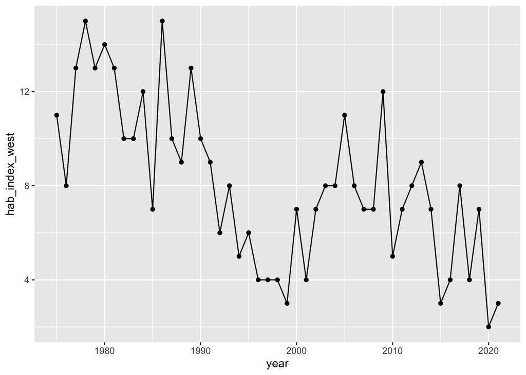

```r
hab_index_west <- ggplot2::ggplot(data=hab, ggplot2::aes(x=.data$year, y=.data$hab_index_west)) +
  ggplot2::geom_point() +
  ggplot2::geom_line()

hab_index_west
```

# Plot the HAB Index Timeseries (Eastern Maine)

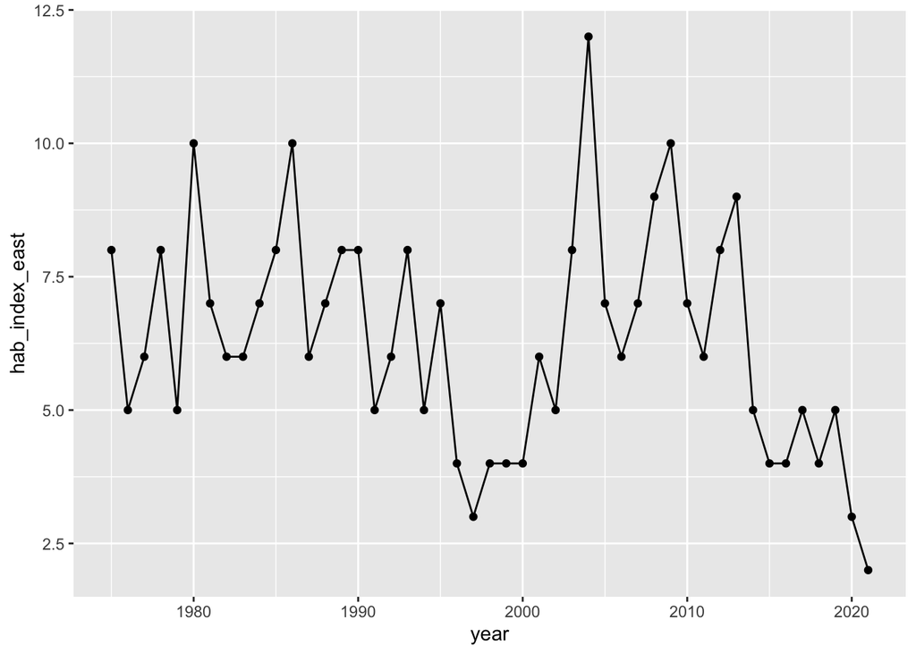

```r
hab_index_east <- ggplot2::ggplot(data=hab, ggplot2::aes(x=.data$year, y=.data$hab_index_east)) +
  ggplot2::geom_point() +
  ggplot2::geom_line()

hab_index_east
```

# Plot Percent Toxic Stations

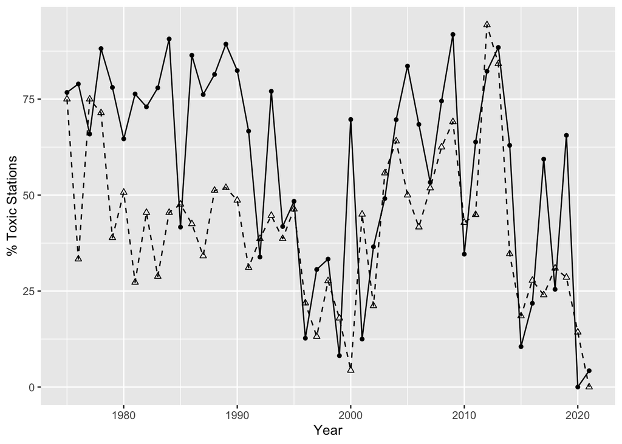

```r
percent_toxic_stations <- ggplot2::ggplot() +
  ggplot2::geom_point(data = hab, ggplot2::aes(x = .data$year, y=.data$per_toxic_stations_west), shape=16) +
  ggplot2::geom_line(data = hab, ggplot2::aes(x = .data$year, y=.data$per_toxic_stations_west)) +
  ggplot2::geom_point(data = hab, ggplot2::aes(x = .data$year, y=.data$per_toxic_stations_east), shape=2) +
  ggplot2::geom_line(data = hab, ggplot2::aes(x = .data$year, y=.data$per_toxic_stations_east), linetype="dashed") +
  ggplot2::labs(x = "Year",
                y = "% Toxic Stations")

percent_toxic_stations
```

# Plot Normalized Cummulative Toxicity

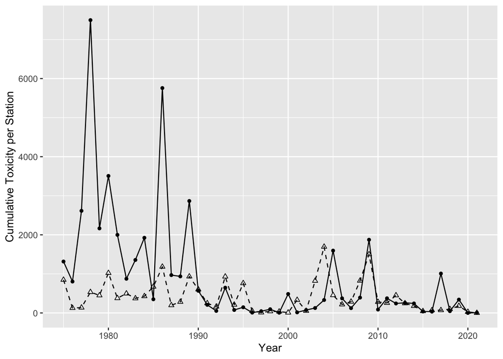

```r
cummulative_toxicity <- ggplot2::ggplot() +
  ggplot2::geom_point(data = hab, ggplot2::aes(x = .data$year, y=.data$norm_tox_west), shape=16) +
  ggplot2::geom_line(data = hab, ggplot2::aes(x = .data$year, y=.data$norm_tox_west)) +
  ggplot2::geom_point(data = hab, ggplot2::aes(x = .data$year, y=.data$norm_tox_east), shape=2) +
  ggplot2::geom_line(data = hab, ggplot2::aes(x = .data$year, y=.data$norm_tox_east), linetype="dashed") +
  ggplot2::labs(x = "Year",
                y = "Cumulative Toxicity per Station")

cummulative_toxicity
```

# Plot the Duration of Toxicity Seasons

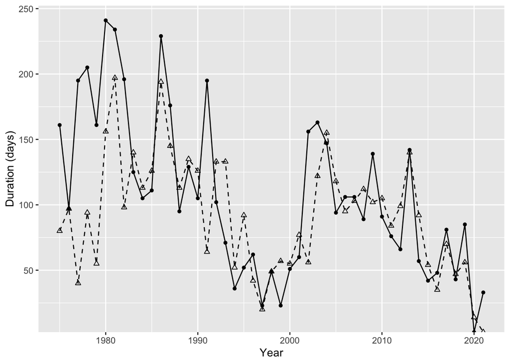

```r
toxic_duration <- ggplot2::ggplot() +
  ggplot2::geom_point(data = hab, ggplot2::aes(x = .data$year, y=.data$duration_west), shape=16) +
  ggplot2::geom_line(data = hab, ggplot2::aes(x = .data$year, y=.data$duration_west)) +
  ggplot2::geom_point(data = hab, ggplot2::aes(x = .data$year, y=.data$duration_east), shape=2) +
  ggplot2::geom_line(data = hab, ggplot2::aes(x = .data$year, y=.data$duration_east), linetype="dashed") +
  ggplot2::labs(x = "Year",
                y = "Duration (days)")

toxic_duration
```

Assignment Locate and download an ocean time series that is of interest to you. The idea is to start thinking about something you’d like to use for your ocean forecasting project. Walk through the steps above to do some time series plotting of your dataset. You’ll have to put the data into a column .csv file and upload to your Kaggle environment.

The goals of this assignment are

- Get a little more comfortable working in R in Kaggle and working with data
- Get started finding and working with data for use in your final forecasting project

Some possible places to find data:

- Ocean ecosystem indicators https://noaa-edab.github.io/tech-doc/
- Global fish stock time series http://www.seaaroundus.org
- Maine landings data https://www.maine.gov/dmr/commercial-fishing/landings/historical-data.html
- NOAA climate indices https://psl.noaa.gov/data/climateindices/list/
- Satellite ocean data https://oceancolor.gsfc.nasa.gov/